# H7F5633

Anton Hellberg

2025-03-14

*Task 4 - R basic operations*

**1. What is the square root of 10?**

```r
sqrt(10)
```

```
## [1] 3.162278
```

**2. What is the logarithm of 32 to the base 2?**

```r
log2(32)
```

```
## [1] 5
```

**3. What is the sum of the numbers from 1 to 1000?**

```r
sum(1:1000)
```

```
## [1] 500500
```

**4. What is the sum of all even numbers from 2 to 1000?**

```r
sum(seq(2, 1000, by=2))
```

```
## [1] 250500
```

**5. How many pairwise comparisons are there for 100 genes?**

```r
100*99/2
```

```
## [1] 4950
```

**6. And how many ways to arrange 100 genes in triples?**

```r
100*99*98/6
```

```
## [1] 161700
```

*Task 5 - Using R example datasets*

**1. Use the R internal CO2 dataset (“data(CO2)”).**

**2. Describe briefly the content of the CO2 dataset using the help function.**

*Answer: The CO2 data frame has 84 rows and 5 columns of data from an experiment on the cold tolerance of the grass species Echinochloa crus-galli. The columns are: Plant, Type, Treatment, conc, uptake.*

**3. What is the average and median CO2 uptake of the plants from Quebec and Mississippi?**

```r
mean(CO2$uptake[CO2$Type == "Mississippi"])
```

```
## [1] 20.88333
```

```r
median(CO2$uptake[CO2$Type == "Mississippi"])
```

```
## [1] 19.3
```

```r
mean(CO2$uptake[CO2$Type == "Quebec"])
```

```
## [1] 33.54286
```

```r
median(CO2$uptake[CO2$Type == "Quebec"])
```

```
## [1] 37.15
```

**4. [Optional] In the “airway” example data from Bioconductor, how many genes are expressed in each sample? How many genes are not expressed in any sample?**

*I could not complete this as Bioconductor was unable to be installed, I will try to fix this the coming days.*

*Task 6 - R Functions*

**1. Write a function that calculates the ratio of the mean and the median of a given vector. This is a helpful measure to detect data with outlying values. Note: See Reference for R language**

*answer: mean(x)/median(x)*

**2. Write a function that ignores the lowest and the highest value from a given vector and calculate the mean.** *answer: mean(x[-c(min(x), max(x))])*

**3. Read about piping from here:https://r4ds.had.co.nz/pipes.html#pipes (you don’t have to learn everything, a basic understanding of the usage is enough). Write a short (max. 300 characters, no spaces) explanation of why, how, and when not to use pipes.**

*Answer: For example if I were to create a plot using ggplot. Creating one long pipe could make debugging the code a challenge. Therefore it would be better to subdivide the ggplot into functioning parts and applying layers to add more features. So in essence, if you will have a long pipe, it is better to choose an alterantive.*

**4. Familiarize yourself with the apply-family of functions (apply, lapply, sapply etc.) http://uc-r.github.io/apply_family Write a short explanation (max. 300 characters, no spaces) of why they could be useful in your work.**

*Answer: Apply can be used as a fast means to understand the data, such as quickly examining means or medians. And as I used lapply later in this assigment, it is good for repetetive tasks such as transforming data or applying models. In summary, apply is suitable for fast actions and also for actions that are repetetive.*

*Task 7 - Basic visualization with R*

```r
magic_guys <- read.csv("~/Library/CloudStorage/OneDrive-KarolinskaInstitutet/Doktoreringen/22. R/Projekt/Bioinformatics Analysis and Visualisation of Medical Genomics Data - VT2025/magic_guys.csv")
```

**1. Compare the distributions of the body heights of the two species from the ‘magic_guys.csv’ dataset graphically**

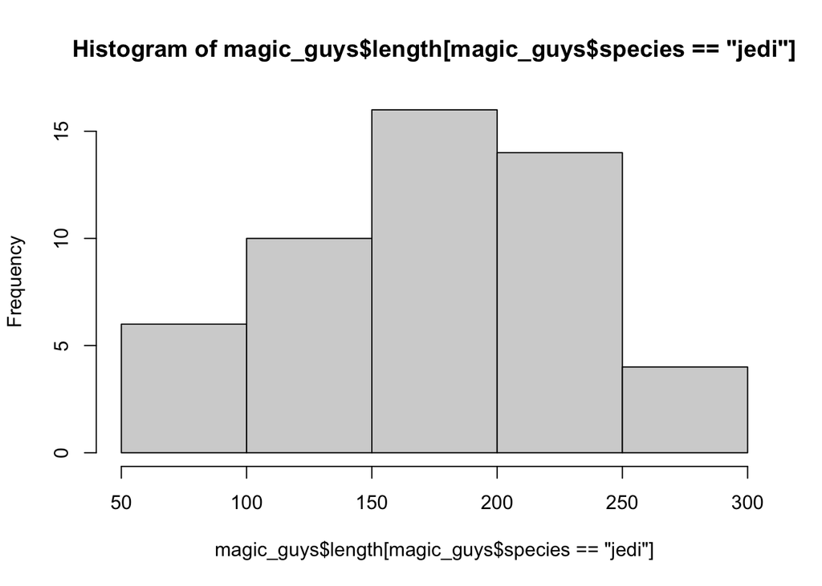

```r
hist(magic_guys$length[magic_guys$species == "jedi"])
```

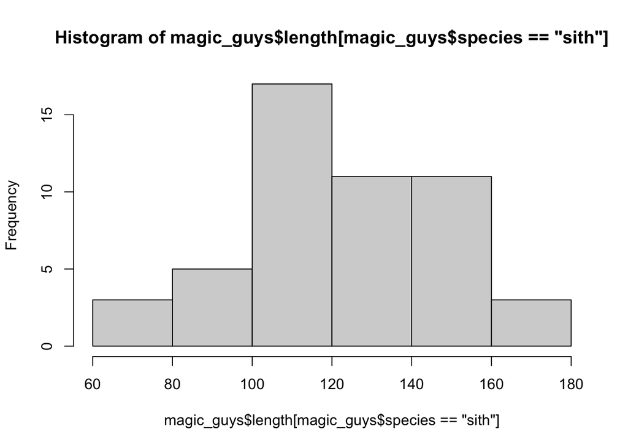

```r
hist(magic_guys$length[magic_guys$species == "sith"])
```

```r
## Histograms are primarily used for distribution, this command lets you choose to see the distribution of heights and also specifically the two separate [magic_guys$species == "sith"] species. ##
```

**a. using the basic ‘hist’ function as well as ‘ggplot’ and ‘geom_histogram’ functions from the ggplot2 package. Optimize the plots for example by trying several different ‘breaks’. Note that ggplot2-based functions give you many more options for changing the visualization parameters, try some of them.**

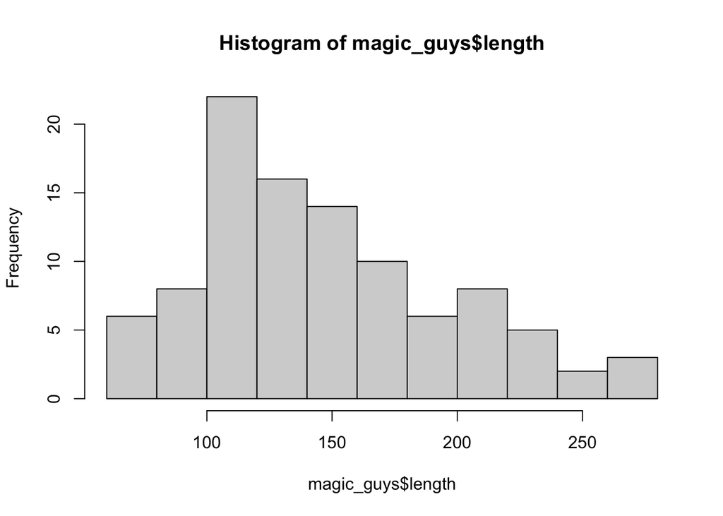

```r
hist(magic_guys$length)
```

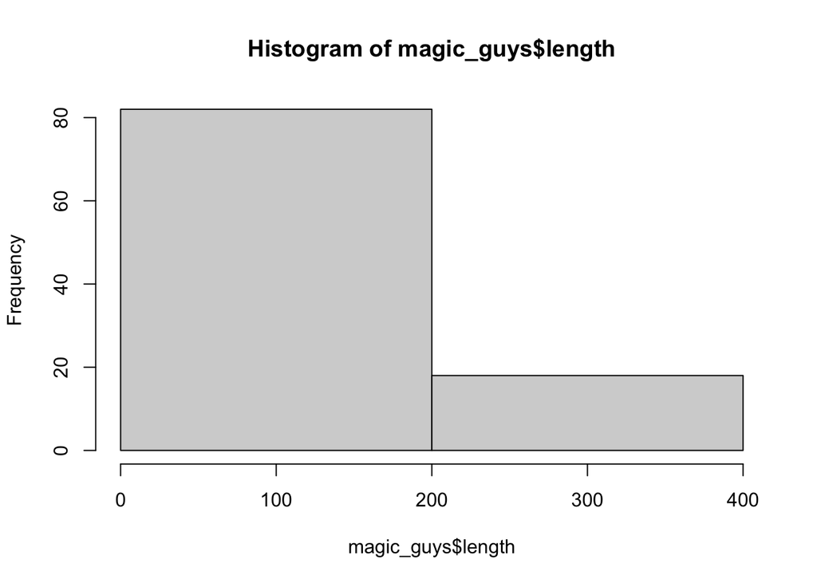

```r
hist(magic_guys$length, breaks = 1) ## only specifies approximately how many bins I want
```

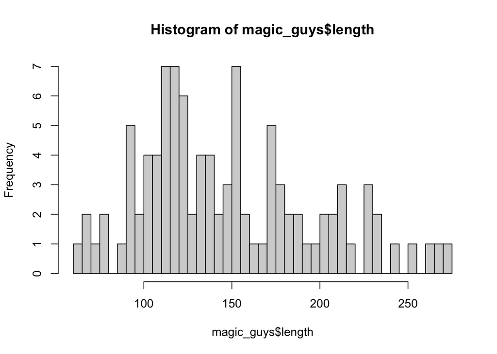

```r
hist(magic_guys$length, breaks = 50)## only specifies approximately how many bins I want
```

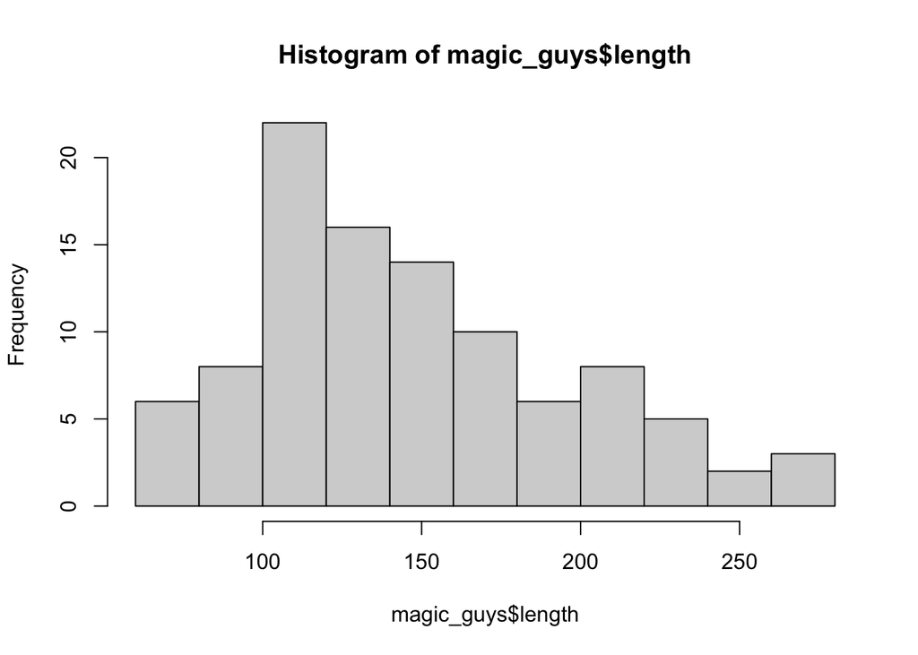

```r
hist(magic_guys$length, breaks = 10)## only specifies approximately how many bins I want
```

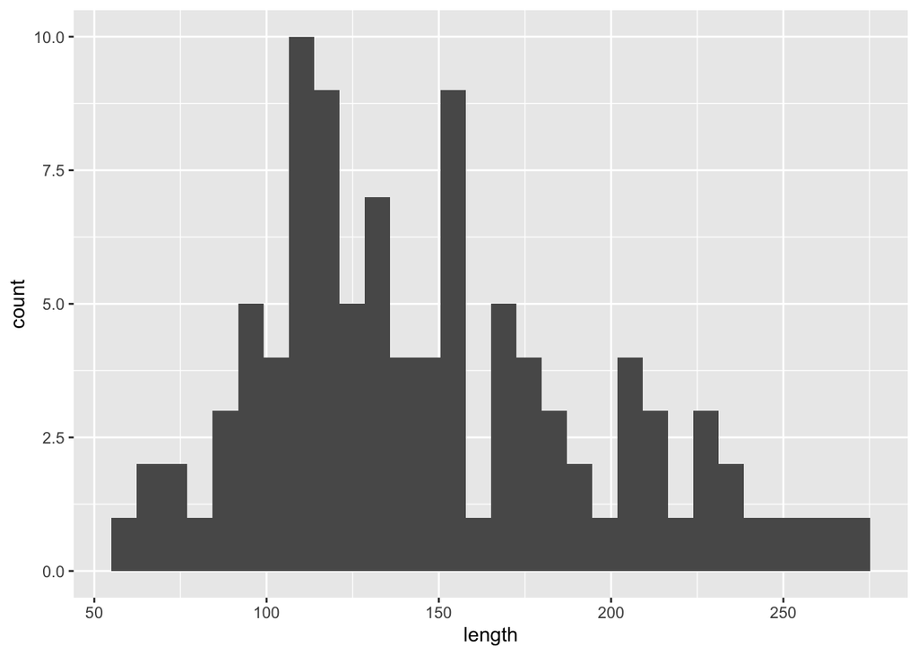

```r
#I deem 10 breaks to be the most optimal to correctly visualize the distribution of lengths

library(ggplot2)
library(tidyr)
library(dplyr)
magic_guys %>%
ggplot(aes(x=length)) +
geom_histogram()
```

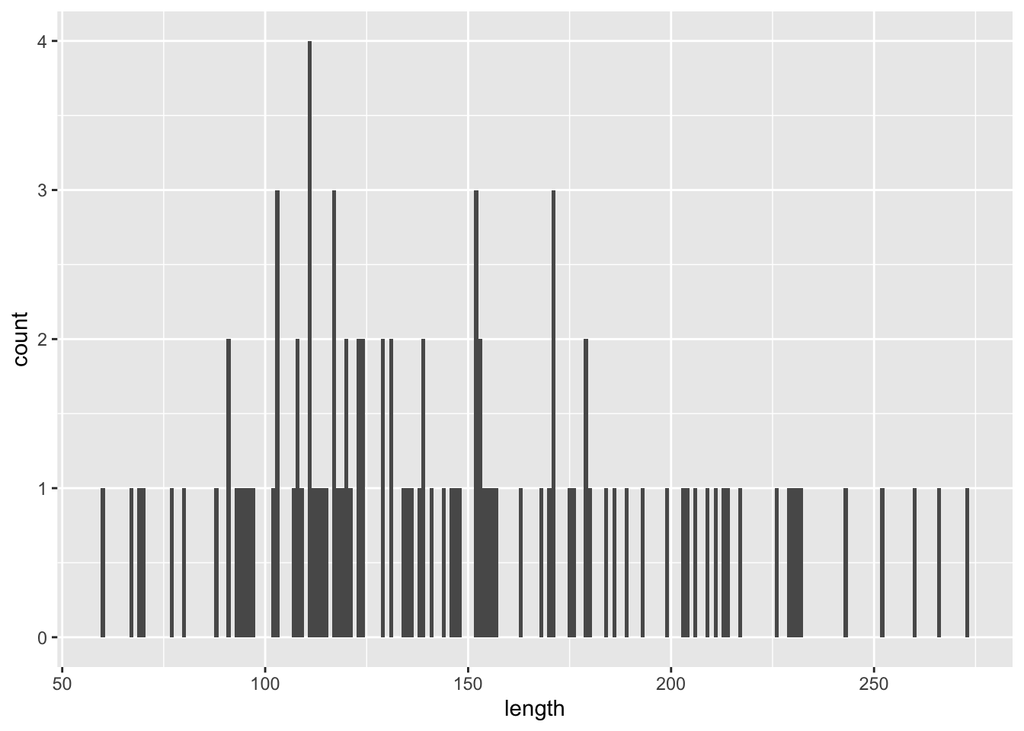

```r
magic_guys %>%
ggplot(aes(x=length)) +
geom_histogram(binwidth=1) #Tells the width of each bin, so reverse to the hist(x, breaks = y) function
```

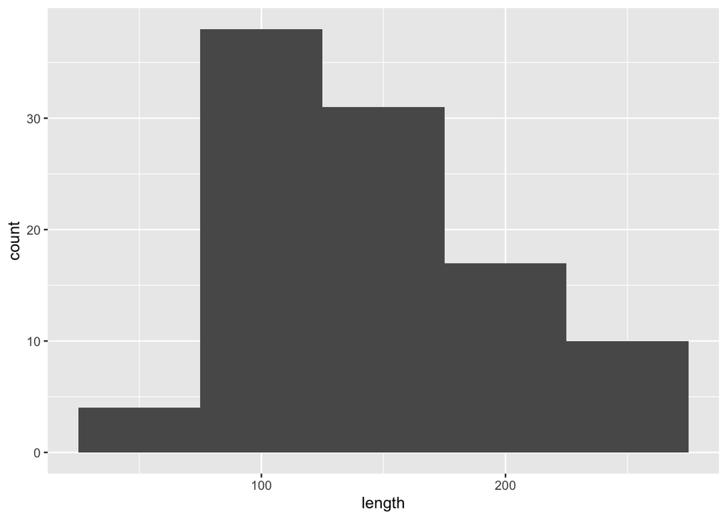

```r
magic_guys %>%
ggplot(aes(x=length)) +
geom_histogram(binwidth=50) #Tells the width of each bin, so reverse to the hist(x, breaks = y) function
```

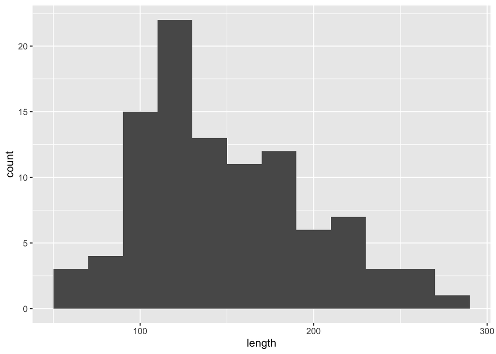

```r
magic_guys %>%
ggplot(aes(x=length)) +
geom_histogram(binwidth=20)
```

```r
#I deem a binwidth of 20 is best for vizualizing the distribution of the data with ggplot
```

**b. Do the same comparison as in a. but with boxplots. If you want to use the ggplot2-package, use the functions ‘ggplot’ and ‘geom_boxplot’.**

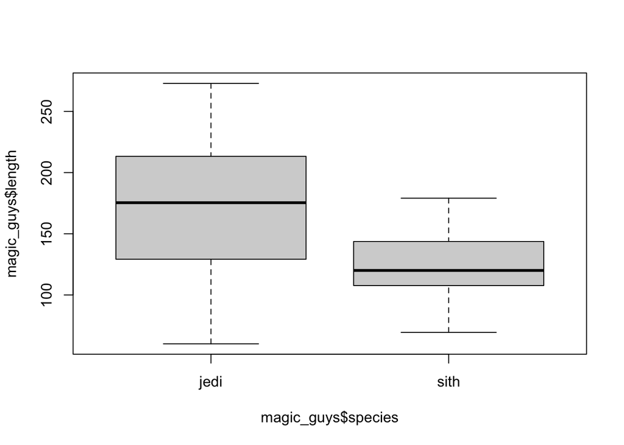

```r
boxplot(magic_guys$length ~ magic_guys$species)
```

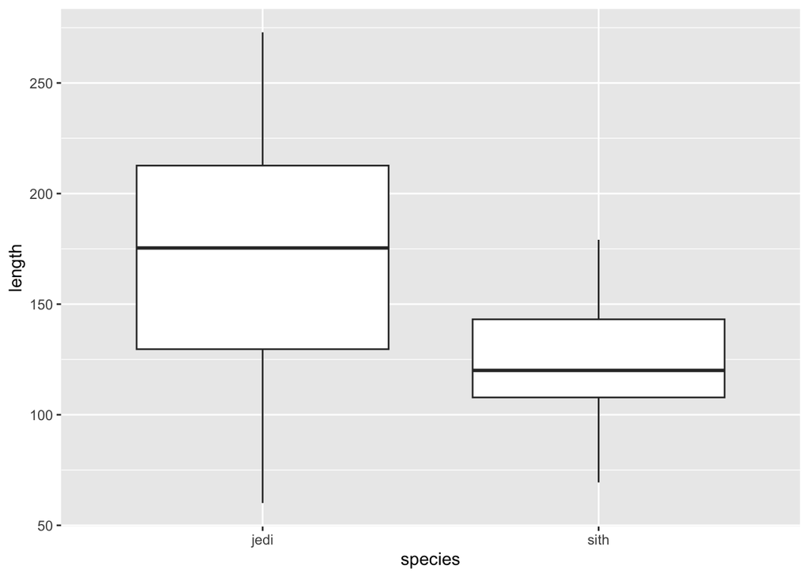

```r
magic_guys %>%
ggplot(aes(x=species, y=length)) +
geom_boxplot()
```

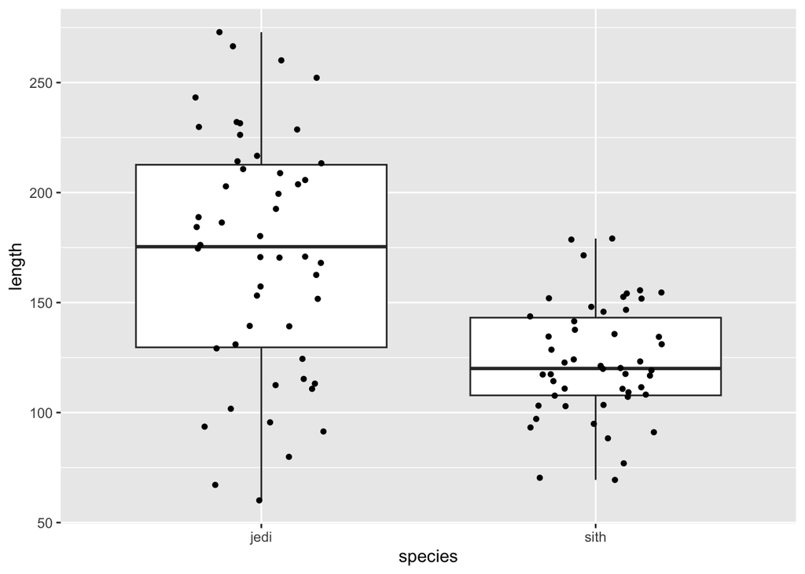

```r
magic_guys %>%
ggplot(aes(x=species, y=length)) +
  geom_boxplot() +
  geom_jitter(shape=16, position=position_jitter(0.2))
```

```r
#This gives the boxplot a good visual overview, both showing the median, IQR and extremes and also the various data points to see how the data is distributed, although the aestethics could be improved.
```

**c. Save the plots with the ‘png’,**

```r
#example
png(file="/Users/antonh/desktop/example.png",
width=600, height=350)
hist(magic_guys$length)
dev.off()
```

**2. Load the gene expression data matrix from the ‘microarray_data.tab’ dataset provided in the shared folder, it is a big tabular separated matrix.**

```r
microarray_data <- read.delim("~/Library/CloudStorage/OneDrive-KarolinskaInstitutet/Doktoreringen/22. R/Projekt/Bioinformatics Analysis and Visualisation of Medical Genomics Data - VT2025/Bioinformatics H7F5633 VT 2025/microarray_data.tab")
```

**a. How big is the matrix in terms of rows and columns?**

```r
nrow(microarray_data) #gives the row numbers
```

```
## [1] 553
```

```r
ncol(microarray_data) #gives column numbers
```

```
## [1] 1000
```

```r
#or
dim(microarray_data) #gives the dimension of the data frame; rows and columns.
```

```
## [1]  553 1000
```

**b. Count the missing values per gene and visualize this result.**

```r
colSums(is.na(microarray_data))
```

```
##    g1    g2    g3    g4    g5    g6    g7    g8    g9   g10   g11   g12   g13
##   130   104    74    93    81    30    31    26    12    56    72   105    55
##   g14   g15   g16   g17   g18   g19   g20   g21   g22   g23   g24   g25   g26
##   133    75    67    21   553    13     9   207   190    96   141   122   149
##   g27   g28   g29   g30   g31   g32   g33   g34   g35   g36   g37   g38   g39
##    47    59   210    22    14    52    14    24    70    83    64    91   144
##   g40   g41   g42   g43   g44   g45   g46   g47   g48   g49   g50   g51   g52
##   124   216    64    13    70    61   108    68   404   106    91   230   231
##   g53   g54   g55   g56   g57   g58   g59   g60   g61   g62   g63   g64   g65
##   207   195   553   196   186   553   224   362   198   217   208   210   188
##   g66   g67   g68   g69   g70   g71   g72   g73   g74   g75   g76   g77   g78
##   351   187   189   187   194   185   185   354   203   216   216   245   201
##   g79   g80   g81   g82   g83   g84   g85   g86   g87   g88   g89   g90   g91
##   553   189   188   224   553   213   188   194   192   213   219   229   365
##   g92   g93   g94   g95   g96   g97   g98   g99  g100  g101  g102  g103  g104
##   223   369   353   195   230   250   238   553   204   228   199   192   211
##  g105  g106  g107  g108  g109  g110  g111  g112  g113  g114  g115  g116  g117
##   373   251   261   207   362   187   200   209   210   224   203   205   189
##  g118  g119  g120  g121  g122  g123  g124  g125  g126  g127  g128  g129  g130
##   212   236   260    33    26    25    22    14    48    36    42    18   194
##  g131  g132  g133  g134  g135  g136  g137  g138  g139  g140  g141  g142  g143
##   213   367   198   199   553   185   553   553   191   186    14   177     8
##  g144  g145  g146  g147  g148  g149  g150  g151  g152  g153  g154  g155  g156
##    13    17     8   186   202    21    30   198   186   207   185   188   196
##  g157  g158  g159  g160  g161  g162  g163  g164  g165  g166  g167  g168  g169
##   215   186   188   187    36    27    28    18   212    36     8    23    33
##  g170  g171  g172  g173  g174  g175  g176  g177  g178  g179  g180  g181  g182
##    23   226   376   200   215   193   214   185   224   203   193    10     9
##  g183  g184  g185  g186  g187  g188  g189  g190  g191  g192  g193  g194  g195
##    10    18    32    47    31    44    15    20    36    35    36    61    20
##  g196  g197  g198  g199  g200  g201  g202  g203  g204  g205  g206  g207  g208
##   188    12     8    12   187    12     7    19   215    15    12     8    11
##  g209  g210  g211  g212  g213  g214  g215  g216  g217  g218  g219  g220  g221
##    23   173     9    14     7    29    15    36    15    10    16    10    56
##  g222  g223  g224  g225  g226  g227  g228  g229  g230  g231  g232  g233  g234
##    31    83    52    27    27    12    13    38    44    17    24   188    11
##  g235  g236  g237  g238  g239  g240  g241  g242  g243  g244  g245  g246  g247
##    36    30    39    55    64    38    81    66    65    61    24    26    47
##  g248  g249  g250  g251  g252  g253  g254  g255  g256  g257  g258  g259  g260
##    26    36    23    47   203     2    20    17     8     7    70    34   392
```

[output cut: 99 more lines]

```
##   393   244   225    11    19    85    35    15    35    35    34   108   191
##  g911  g912  g913  g914  g915  g916  g917  g918  g919  g920  g921  g922  g923
##    79    30    20    19    52    15    30    35   553    34    48    71    28
##  g924  g925  g926  g927  g928  g929  g930  g931  g932  g933  g934  g935  g936
##    55    44   192    19    10    30    26   185   376   224   232   192   250
##  g937  g938  g939  g940  g941  g942  g943  g944  g945  g946  g947  g948  g949
##   217   202   228   199    18    17    22    10    70    32   199    69    36
##  g950  g951  g952  g953  g954  g955  g956  g957  g958  g959  g960  g961  g962
##    13   187    57    31    12    21    68    26    26    16    19    14    53
##  g963  g964  g965  g966  g967  g968  g969  g970  g971  g972  g973  g974  g975
##    56    20    83    10    11    14    26   191   553   225   228   222   211
##  g976  g977  g978  g979  g980  g981  g982  g983  g984  g985  g986  g987  g988
##   227   184   195   205   354    11    50    10    32   188    13    13    14
##  g989  g990  g991  g992  g993  g994  g995  g996  g997  g998  g999 g1000
##   201    21    13    13    20    29    12    33    18    19    24    17
```

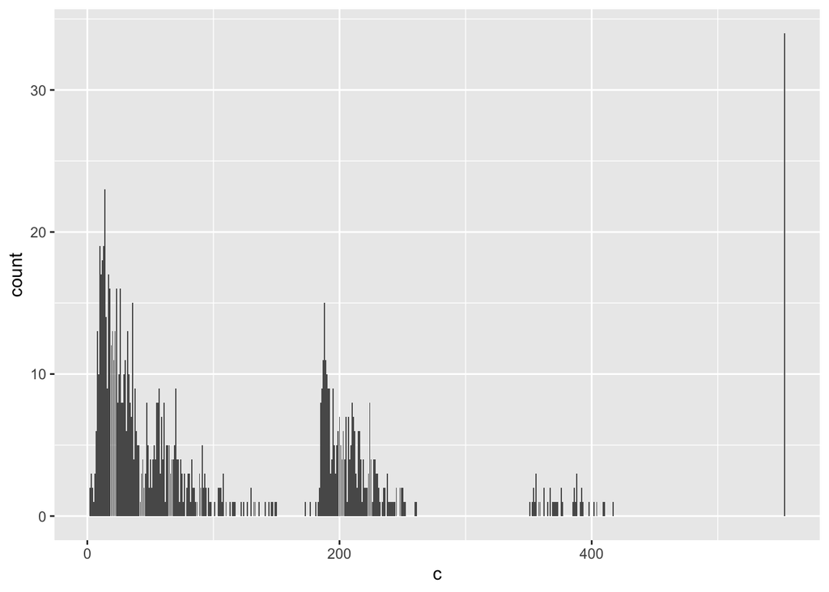

```r
c <- colSums(is.na(microarray_data))
c <- data.frame(c)
c %>%
  ggplot(aes(x = c)) +
  geom_bar()
```

**c. Find the genes for which there are more than X% (X=10%, 20%, 50%) missing values.**

```r
c <- colSums(is.na(microarray_data))
names(c[c > 0.1 * ncol(microarray_data)])
```

```
##   [1] "g1"   "g2"   "g12"  "g14"  "g18"  "g21"  "g22"  "g24"  "g25"  "g26"
##  [11] "g29"  "g39"  "g40"  "g41"  "g46"  "g48"  "g49"  "g51"  "g52"  "g53"
##  [21] "g54"  "g55"  "g56"  "g57"  "g58"  "g59"  "g60"  "g61"  "g62"  "g63"
##  [31] "g64"  "g65"  "g66"  "g67"  "g68"  "g69"  "g70"  "g71"  "g72"  "g73"
##  [41] "g74"  "g75"  "g76"  "g77"  "g78"  "g79"  "g80"  "g81"  "g82"  "g83"
##  [51] "g84"  "g85"  "g86"  "g87"  "g88"  "g89"  "g90"  "g91"  "g92"  "g93"
##  [61] "g94"  "g95"  "g96"  "g97"  "g98"  "g99"  "g100" "g101" "g102" "g103"
##  [71] "g104" "g105" "g106" "g107" "g108" "g109" "g110" "g111" "g112" "g113"
##  [81] "g114" "g115" "g116" "g117" "g118" "g119" "g120" "g130" "g131" "g132"
##  [91] "g133" "g134" "g135" "g136" "g137" "g138" "g139" "g140" "g142" "g147"
## [101] "g148" "g151" "g152" "g153" "g154" "g155" "g156" "g157" "g158" "g159"
## [111] "g160" "g165" "g171" "g172" "g173" "g174" "g175" "g176" "g177" "g178"
## [121] "g179" "g180" "g196" "g200" "g204" "g210" "g233" "g252" "g260" "g290"
## [131] "g296" "g297" "g301" "g321" "g329" "g332" "g333" "g334" "g335" "g344"
## [141] "g351" "g352" "g353" "g354" "g355" "g356" "g357" "g358" "g359" "g360"
```

[output cut: 24 more lines]

```r
names(c[c > 0.2 * ncol(microarray_data)])
```

```
##   [1] "g18"  "g21"  "g29"  "g41"  "g48"  "g51"  "g52"  "g53"  "g55"  "g58"
##  [11] "g59"  "g60"  "g62"  "g63"  "g64"  "g66"  "g73"  "g74"  "g75"  "g76"
##  [21] "g77"  "g78"  "g79"  "g82"  "g83"  "g84"  "g88"  "g89"  "g90"  "g91"
##  [31] "g92"  "g93"  "g94"  "g96"  "g97"  "g98"  "g99"  "g100" "g101" "g104"
##  [41] "g105" "g106" "g107" "g108" "g109" "g112" "g113" "g114" "g115" "g116"
##  [51] "g118" "g119" "g120" "g131" "g132" "g135" "g137" "g138" "g148" "g153"
##  [61] "g157" "g165" "g171" "g172" "g174" "g176" "g178" "g179" "g204" "g252"
##  [71] "g260" "g290" "g301" "g329" "g351" "g352" "g353" "g355" "g356" "g357"
##  [81] "g358" "g359" "g360" "g362" "g363" "g364" "g367" "g368" "g370" "g379"
##  [91] "g381" "g382" "g383" "g384" "g385" "g386" "g387" "g388" "g389" "g390"
## [101] "g391" "g396" "g401" "g404" "g405" "g406" "g410" "g417" "g418" "g431"
## [111] "g432" "g433" "g436" "g437" "g438" "g439" "g440" "g455" "g461" "g462"
## [121] "g465" "g466" "g469" "g470" "g491" "g493" "g496" "g497" "g498" "g515"
## [131] "g518" "g519" "g527" "g531" "g532" "g535" "g536" "g537" "g538" "g540"
## [141] "g547" "g558" "g561" "g569" "g571" "g572" "g573" "g575" "g576" "g577"
## [151] "g585" "g612" "g613" "g614" "g615" "g617" "g618" "g619" "g650" "g657"
## [161] "g663" "g669" "g689" "g751" "g753" "g754" "g756" "g758" "g759" "g760"
## [171] "g763" "g765" "g766" "g768" "g782" "g783" "g784" "g785" "g786" "g787"
## [181] "g788" "g789" "g801" "g802" "g804" "g806" "g807" "g808" "g809" "g810"
## [191] "g832" "g833" "g836" "g838" "g850" "g851" "g854" "g862" "g863" "g864"
## [201] "g865" "g867" "g869" "g870" "g892" "g893" "g894" "g896" "g897" "g898"
## [211] "g899" "g900" "g919" "g932" "g933" "g934" "g936" "g937" "g938" "g939"
## [221] "g971" "g972" "g973" "g974" "g975" "g976" "g979" "g980" "g989"
```

```r
names(c[c > 0.5 * ncol(microarray_data)])
```

```
##  [1] "g18"  "g55"  "g58"  "g79"  "g83"  "g99"  "g135" "g137" "g138" "g329"
## [11] "g352" "g368" "g389" "g390" "g417" "g431" "g498" "g519" "g527" "g531"
## [21] "g538" "g576" "g577" "g615" "g751" "g753" "g788" "g802" "g838" "g864"
## [31] "g892" "g893" "g919" "g971"
```

**d. Replace the missing values by the average expression value for the particular gene. (Note: Imputing data has to be used with caution!)**

```r
microarray_data_imputed <- data.frame(lapply(microarray_data, function(x){ifelse(is.na(x), mean(x, na.rm = TRUE), x)}))
```

**3. Visualize the data in the CO2 dataset in a way that gives you a deeper understanding of the data. What do you see?**

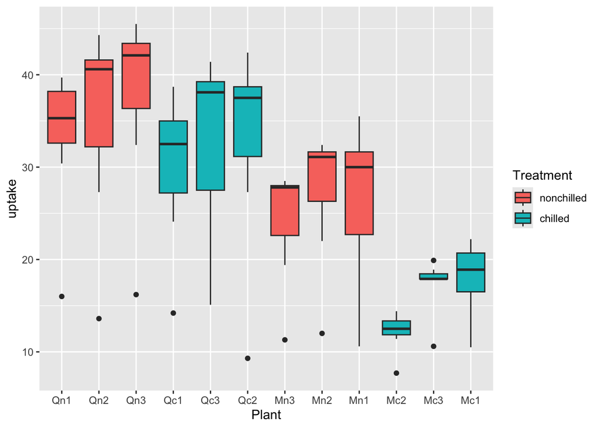

```r
CO2 %>%
ggplot(aes(x=Plant, y=uptake, fill=Treatment)) +
  geom_boxplot()
```

```r
## That Quebec plants (Qn1-3 and Qc1-3) have a higher uptake and also that nonchilled plants have a slightly higher uptake than chilled plants. ##
```

*Task 8*

**1. Install the Tidybiology package, which includes the data ‘chromosome’ and ‘proteins’ devtools::install_github(“hirscheylab/tidybiology”)**

```r
library(tidybiology)
library(ggpubr)
```

**a. Extract summary statistics (mean, median and maximum) for the following variables from the ‘chromosome’ data: variations, protein coding genes, and miRNAs. Utilize the tidyverse functions to make this as simply as possible.**

```r
chromosome %>%
  select(protein_codinggenes, variations, mi_rna) %>%
  summary()
```

```
##  protein_codinggenes   variations           mi_rna
##  Min.   :  71.0      Min.   :  211643   Min.   : 15.00
##  1st Qu.: 595.8      1st Qu.: 4395298   1st Qu.: 55.75
##  Median : 836.0      Median : 6172346   Median : 75.00
##  Mean   : 850.0      Mean   : 6484572   Mean   : 73.17
##  3rd Qu.:1055.5      3rd Qu.: 8742592   3rd Qu.: 92.00
##  Max.   :2058.0      Max.   :12945965   Max.   :134.00
```

**b. How does the chromosome size distribute? Plot a graph that helps to visualize this by using ggplot2 package functions.**

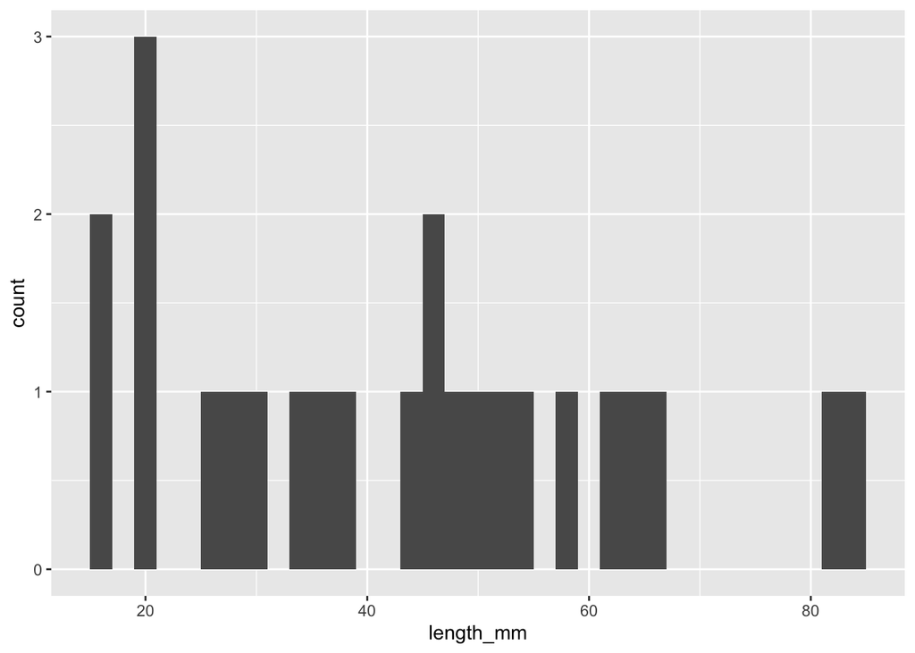

```r
chromosome %>%
  ggplot(aes(x=length_mm)) +
  geom_histogram(binwidth=2)
```

**c. Does the number of protein coding genes or miRNAs correlate with the length of the chromosome? Make two separate plots to visualize these relationships.**

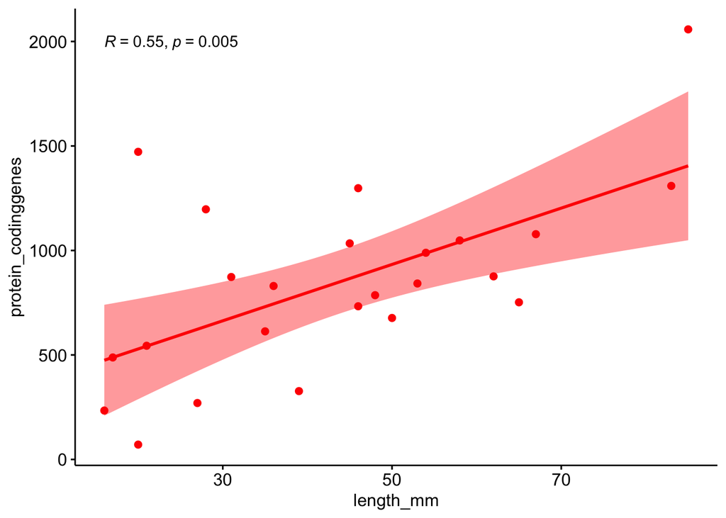

```r
chromosome %>%
  ggscatter(x = "length_mm", y = "protein_codinggenes",
          add = "reg.line", conf.int = TRUE, color = "red",
          cor.coef = TRUE, cor.method = "spearman")
```

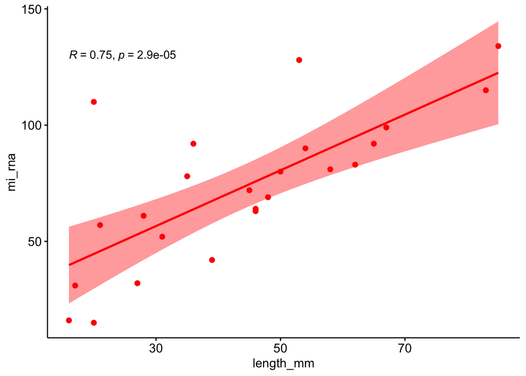

```r
chromosome %>%
  ggscatter(x = "length_mm", y = "mi_rna",
          add = "reg.line", conf.int = TRUE, color = "red",
          cor.coef = TRUE, cor.method = "spearman")
```

```r
## Both protein coding genes and miRNAs correlate with the length of the chromosome, which would be expected. However miRNAs corrates stronger than protein coding genes ##
```

**d. Calculate the same summary statistics for the ‘proteins’ data variables length and mass. Create a meaningful visualization of the relationship between these two variables by utilizing the ggplot2 package functions. Play with the colors, theme- and other visualization parameters to create a plot that pleases you.**

```r
proteins %>%
  select(length, mass) %>%
  summary()
```

```
##      length             mass
##  Min.   :    2.0   Min.   :    260
##  1st Qu.:  251.0   1st Qu.:  27940
##  Median :  414.0   Median :  46140
##  Mean   :  557.2   Mean   :  62061
##  3rd Qu.:  669.0   3rd Qu.:  74755
##  Max.   :34350.0   Max.   :3816030
```

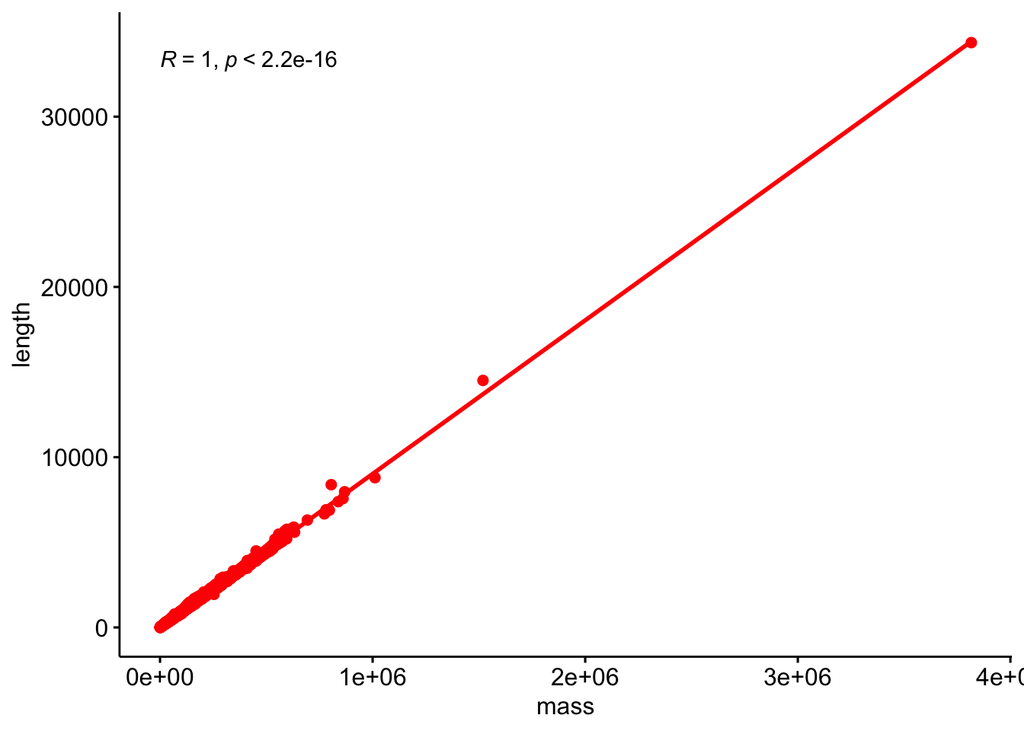

```r
proteins %>%
  ggscatter(x = "mass", y = "length",
          add = "reg.line", color = "red",
          cor.coef = TRUE, cor.method = "spearman")
```

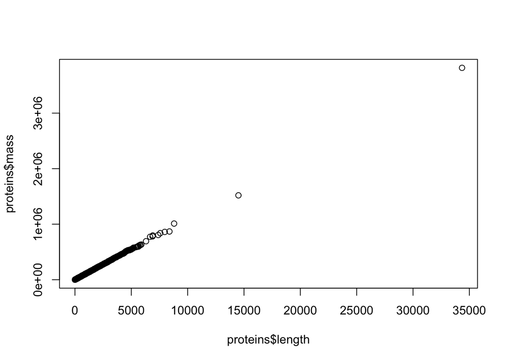

```r
qqplot(proteins$length, proteins$mass)
```

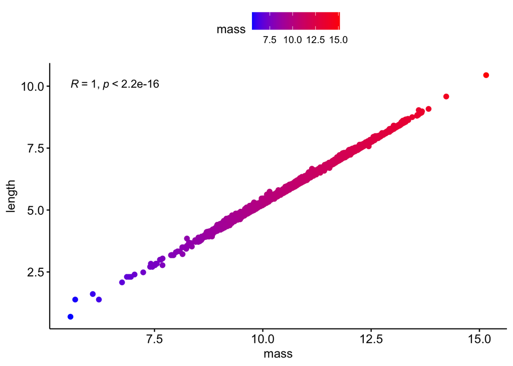

```r
proteins_log <- data.frame(lapply(proteins, function(x) if(is.numeric(x)) log(x) else x)) ## Data seems to be skewed.

proteins_log %>%
  ggscatter(x = "mass", y = "length",
          color = "mass",
          cor.coef = TRUE, cor.method = "pearson", conf.int = TRUE) + #changed to pearson as the data now has normal distribution
  scale_color_gradient(low = "blue", high = "red")
```